# Lab #2 - Gapminder Dataset

# Plotting summarized data

By combining `summarize` and `group_by` with `ggplot`, it’s easy to make plots of grouped data. For example, here’s how we could plot total world population in millions from 1952 to 2007. First we construct a tibble which I’ll name `by_year` containing the desired summary statistic grouped by year and display it:

```r
by_year <- gapminder %>%
  mutate(popMil = pop / 1000000) %>%
  group_by(year) %>%
  summarize(totalpopMil = sum(popMil))
by_year
```

```
# A tibble: 12 x 2
    year totalpopMil
   <int>       <dbl>
 1  1952       2407.
 2  1957       2664.
 3  1962       2900.
 4  1967       3217.
 5  1972       3577.
 6  1977       3930.
 7  1982       4289.
 8  1987       4691.
 9  1992       5111.
10  1997       5515.
11  2002       5887.
12  2007       6251.
```

Then we make a scatterplot using `ggplot`:

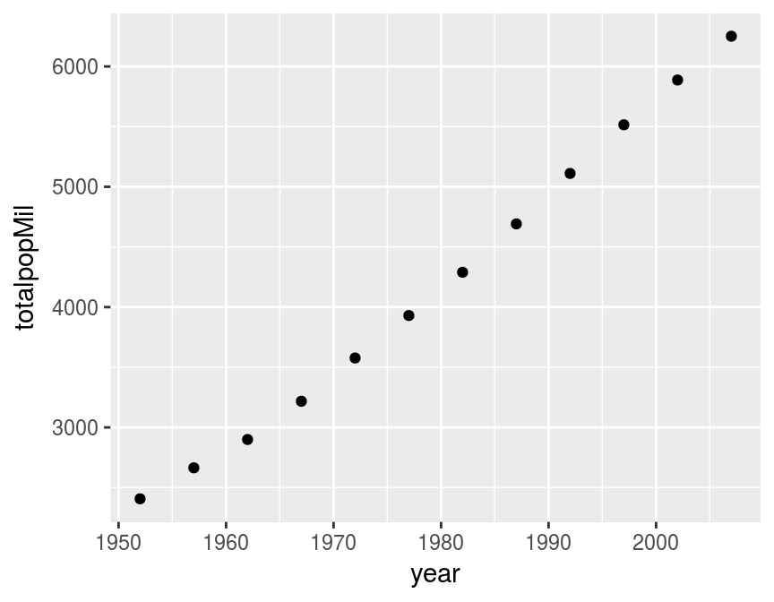

```r
ggplot(by_year) +
  geom_point(aes(x = year, y = totalpopMil))
```

Here’s a more complicated example where we additionally use color to plot each continent separately:

```r
by_year_continent <- gapminder %>%
  mutate(popMil = pop / 1000000) %>%
  group_by(year, continent) %>%
  summarize(totalpopMil = sum(popMil))
by_year
```

```
# A tibble: 12 x 2
    year totalpopMil
   <int>       <dbl>
 1  1952       2407.
 2  1957       2664.
 3  1962       2900.
 4  1967       3217.
 5  1972       3577.
 6  1977       3930.
 7  1982       4289.
 8  1987       4691.
 9  1992       5111.
10  1997       5515.
11  2002       5887.
12  2007       6251.
```

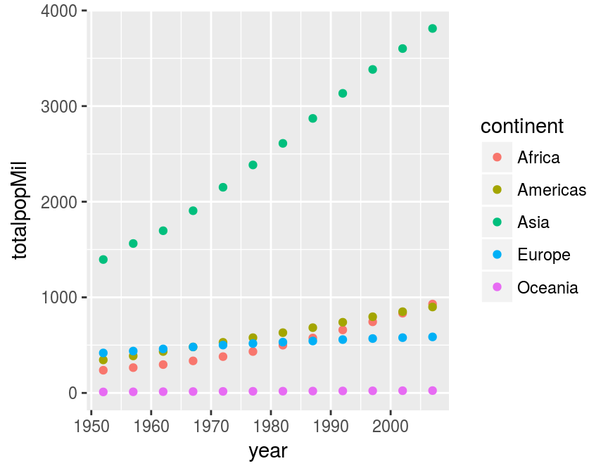

```r
ggplot(by_year_continent) +
  geom_point(aes(x = year, y = totalpopMil, color = continent))
```

Make sure you understand how the preceding example works before attempting the exercise.

# Exercise #5

1. What happens if you append `+ expand_limits(y = 0)` to the preceding `ggplot` code? Why might this be helpful in some cases?
2. Make a scatter with average GDP per capita across all countries in `gapminder` in the y-axis and `year` on the x-axis.
3. Repeat 2. broken down by continent, using color to distinguish the points. Put mean GDP per capita on the log scale.

# Solution to Exercise #5

*Write your code and solutions here*

1. The function `expand_limits()` lets us tweak the limits of our x or y-axis in a `ggplot`. In this particular example `expand_limits(y = 0)` ensures that the y-axis begins at zero. Without using this command, `ggplot` will choose the y-axis on its own so that there is no “empty space” in the plot. Sometimes we may want to override this behavior.
2. Use the following:

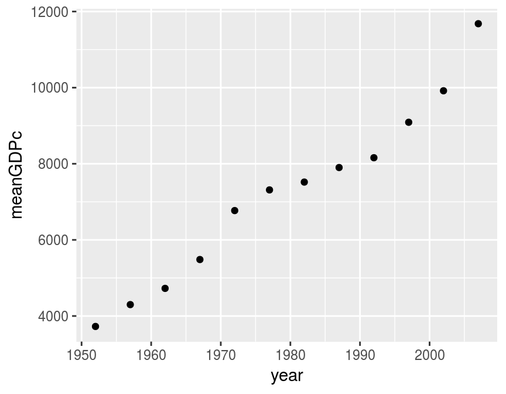

```r
by_year <- gapminder %>%
  group_by(year) %>%
  summarize(meanGDPc = mean(gdpPercap))
ggplot(by_year) +
  geom_point(aes(x = year, y = meanGDPc))
```

3. Use the following

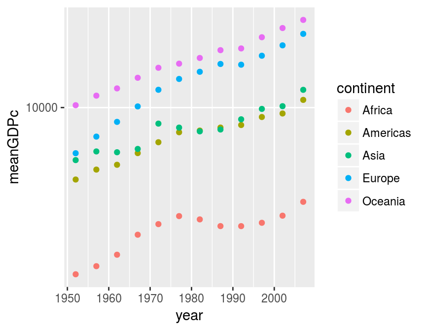

```r
by_year <- gapminder %>%
  group_by(year, continent) %>%
  summarize(meanGDPc = mean(gdpPercap))
ggplot(by_year) +
  geom_point(aes(x = year, y = meanGDPc, color = continent)) +
  scale_y_log10()
```

# Line plots

```r
by_year_continent <- gapminder %>%
  mutate(popMil = pop / 1000000) %>%
  group_by(year, continent) %>%
  summarize(totalpopMil = sum(popMil))
by_year
```

```
# A tibble: 60 x 3
# Groups:   year [?]
    year continent meanGDPc
   <int> <fct>        <dbl>
 1  1952 Africa       1253.
 2  1952 Americas     4079.
 3  1952 Asia         5195.
 4  1952 Europe       5661.
 5  1952 Oceania     10298.
 6  1957 Africa       1385.
 7  1957 Americas     4616.
 8  1957 Asia         5788.
 9  1957 Europe       6963.
10  1957 Oceania     11599.
# ... with 50 more rows
```

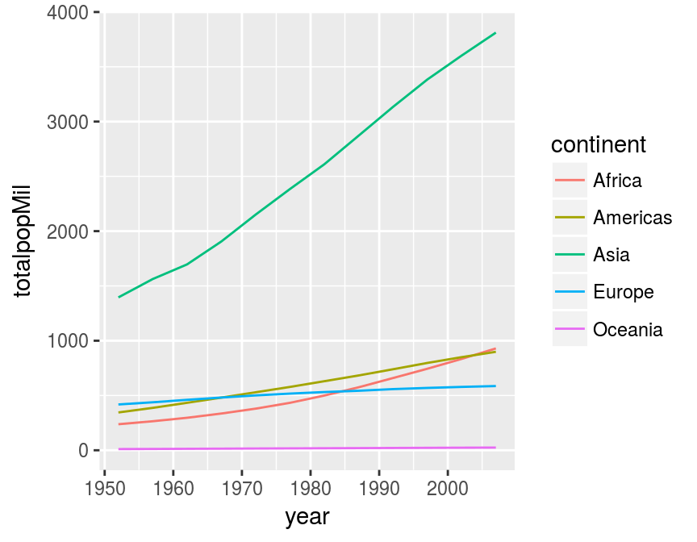

```r
ggplot(by_year_continent) +
  geom_line(aes(x = year, y = totalpopMil, color = continent))
```

# Exercise #6

Repeat exercise 5-3 with a line plot rather than a scatterplot.

# Solution to Exercise #6

*Write your code and solutions here*

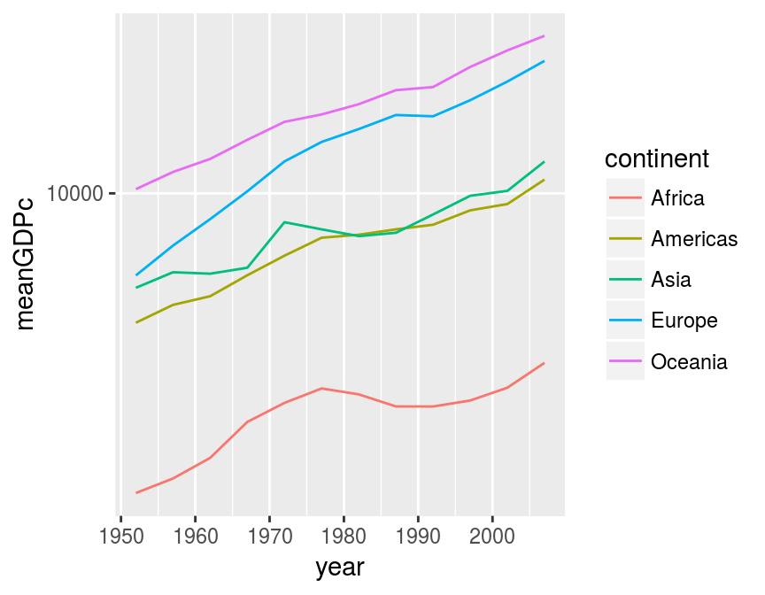

```r
by_year <- gapminder %>%
  group_by(year, continent) %>%
  summarize(meanGDPc = mean(gdpPercap))
ggplot(by_year) +
  geom_line(aes(x = year, y = meanGDPc, color = continent)) +
  scale_y_log10()
```

# Bar plots

To make a bar plot, we use `geom_col()`. Note that the `x` argument of `aes` needs to be a *categorical variable* for a bar plot to make sense. Here’s a simple example:

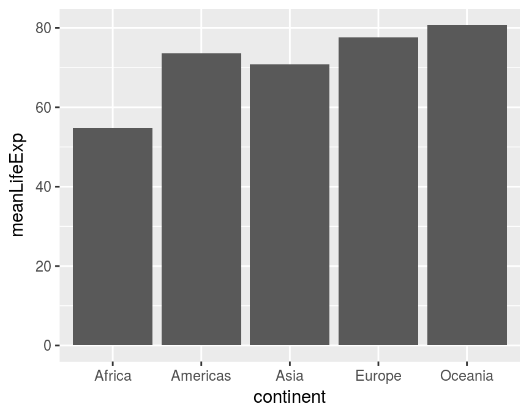

```r
by_continent <- gapminder %>%
  filter(year == 2007) %>%
  group_by(continent) %>%
  summarize(meanLifeExp = mean(lifeExp))
ggplot(by_continent) +
  geom_col(aes(x = continent, y = meanLifeExp))
```

Sometimes we want to turn a bar plot, or some other kind of plot, on its side. This can be particularly helpful if the x-axis labels are very long. To do this, simply add `+ coord_flip()` to your `ggplot` command, for example:

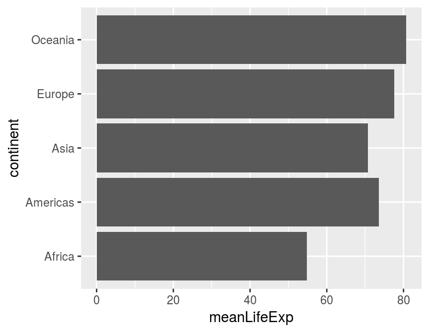

```r
ggplot(by_continent) +
  geom_col(aes(x = continent, y = meanLifeExp)) +
  coord_flip()
```

# Exercise #7

Make a collection of bar plots faceted by year that compare mean GDP per capita across countries in a given year. Orient your plots so it’s easy to read the continent labels.

# Solution to Exercise #7

*Write your code and solutions here*

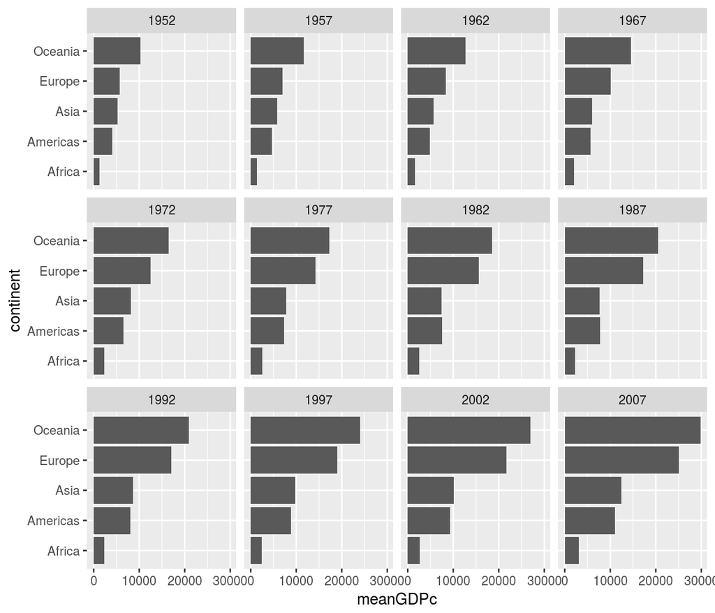

```r
by_continent <- gapminder %>%
  group_by(continent) %>%
  summarize(meanGDPc = mean(gdpPercap))
ggplot(by_year) +
  geom_col(aes(x = continent, y = meanGDPc)) +
  facet_wrap(~ year) +
  coord_flip()
```

# Histograms

To make a `ggplot2` histogram, we use the function `geom_histogram()`. Recall from Econ 103 that a histogram summarizes a *single* variable at a time by forming non-overlapping bins of equal width and calculating the fraction of observations in each bin. If we choose a different width for the bins, we’ll get a different histogram. Here’s an example of two different bin widths:

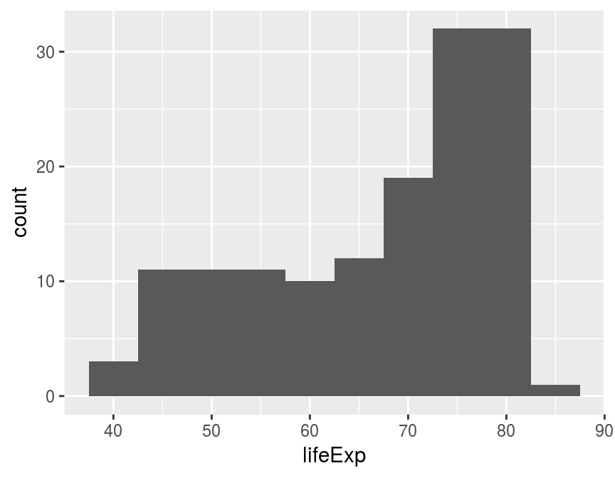

```r
gapminder_2007 <- gapminder %>%
  filter(year == 2007)
ggplot(gapminder_2007) +
  geom_histogram(aes(x = lifeExp), binwidth = 5)
```

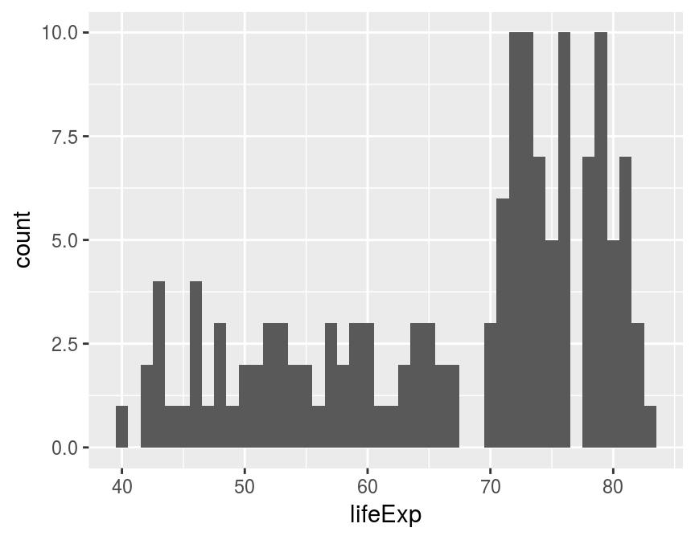

```r
ggplot(gapminder_2007) +
  geom_histogram(aes(x = lifeExp), binwidth = 1)
```

# Exercise # 8

1. All of the examples we’ve seen that use `ggplot` *besides* histograms have involved specifying both `x` and `y` within `aes()`. Why are histograms different?
2. What happens if you don’t specify a bin width in either of my two examples?
3. Make a histogram of GDP per capita in 1977. Play around with different bin widths until you find one that gives a good summary of the data.
4. Repeat 3. but put GDP per capita on the log scale.
5. Compare and contrast the two different histograms you’ve made.

# Solution to Exercise #8

*Write your code and solutions here*

1. This is because histograms only depict a single variable while the other plots we’ve made show two variables at once.
2. If you don’t specify a bin width, `ggplot2` will pick one for you and possibly give you a warning suggesting that you pick a better bin width manually.
3. There’s no obvious *right answer* for the bin width, but here’s one possibility:

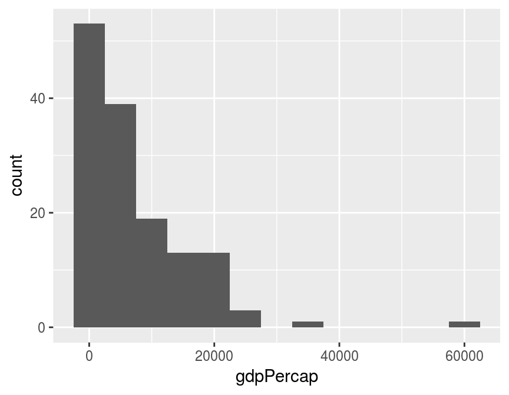

```r
gapminder1977 <- gapminder %>%
  filter(year == 1977)
ggplot(gapminder_1977) +
  geom_histogram(aes(x = gdpPercap), binwidth = 5000)
```

4. You’ll need a much smaller bin width when using the log scale, for example:

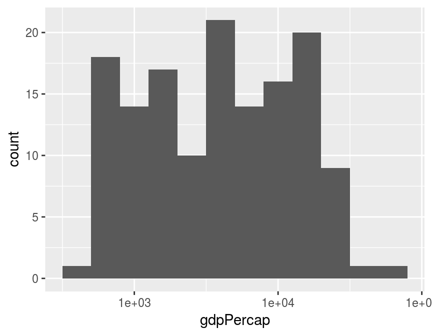

```r
ggplot(gapminder_1977) +
  geom_histogram(aes(x = gdpPercap), binwidth = 0.2) +
  scale_x_log10()
```

5. No right answer: it’s a discussion question! But the idea is to see how taking logs gets rid of the huge positive skewness in GDP per capita.

# Boxplots

The final kind of `ggplot` we’ll learn how to produce is a boxplot. Recall from Econ 103 that a boxplot is a visualization of the *five-number summary* of a variable: minimum, 25th percentile, median, 75th percentile, and maximum. To make a boxplot in `ggplot` we use the function `geom_boxplot()`, for example:

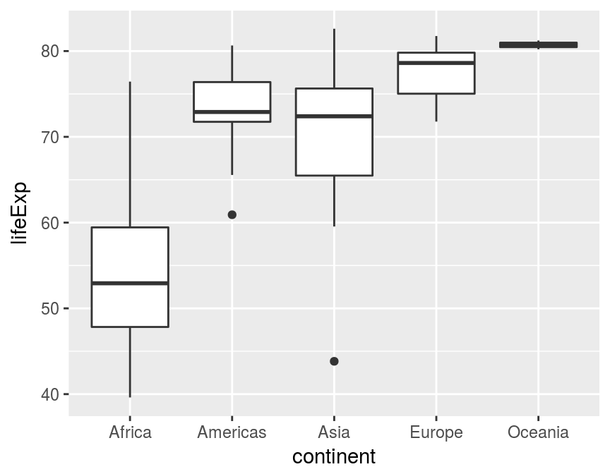

```r
ggplot(gapminder_2007) +
  geom_boxplot(aes(x = continent, y = lifeExp))
```

Compared to histograms, boxplots provide less detail but allow us to easily compare across groups.

# Exercise # 9

1. What is the meaning of the little “dots” that appear in the boxplot above? Use a Google search to find out what they are and how they are computed.
2. Use faceting to construct a collection of boxplots, each of which compares log GDP per capita across continents in a given year.
3. Use a Google search to find out how to add a title to a `ggplot`. Use it to add a title to the plot you created in 2.

# Solution to Exercise #9

*Write your code and solutions here*

1. They are outliers: `ggplot` considers any observation that is more than 1.5 times the interquartile range away from the “box” to be an outlier, and adds a point to indicate it. Turn your boxplots sideways to make it easier to read the continent labels.
2. Use the following code:

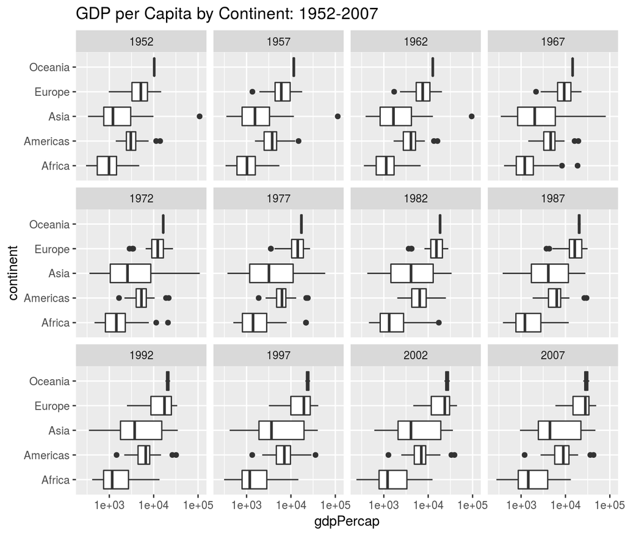

```r
ggplot(gapminder) +
  geom_boxplot(aes(x = continent, y = gdpPercap)) +
  facet_wrap(~ year) +
  scale_y_log10() +
  coord_flip() +
  ggtitle('GDP per Capita by Continent: 1952-2007')
```

3. Use `ggtitle('YOUR TITLE HERE')` as I did in my solution to 2. above.